# Machine Learning with Python

### Linear regression with multiple variables

```python
data2 = pd.read_csv('inputs/linear_Reg_2.csv', header=None, names=['Size', 'Bedrooms', 'Price'])
data2.head()
```

|  | Size | Bedrooms | Price |
| --- | --- | --- | --- |
| 0 | 2104 | 3 | 399900 |
| 1 | 1600 | 3 | 329900 |
| 2 | 2400 | 3 | 369000 |
| 3 | 1416 | 2 | 232000 |
| 4 | 3000 | 4 | 539900 |

```python
data2 = (data2 - data2.mean()) / data2.std()
```

```python
data2.head()
```

|  | Size | Bedrooms | Price |
| --- | --- | --- | --- |
| 0 | 0.130010 | -0.223675 | 0.475747 |
| 1 | -0.504190 | -0.223675 | -0.084074 |
| 2 | 0.502476 | -0.223675 | 0.228626 |
| 3 | -0.735723 | -1.537767 | -0.867025 |
| 4 | 1.257476 | 1.090417 | 1.595389 |

```python
# set X (training data) and y (target variable)
cols = data2.shape[1]
A = data2.iloc[:,0:cols-1]
b = data2.iloc[:,cols-1:cols]

# convert to matrices and initialize theta
A = np.matrix(A.values)
b = np.matrix(b.values)
x = np.matrix(np.zeros(( 1, A.shape[1])))
```

```python
print(A.shape, b.shape, x.shape)
```

```
(47, 2) (47, 1) (1, 2)
```

```python
computeCost(A, b, x)
```

```
0.978723404255319
```

```python
# perform linear regression on the data set
final_x, cost = gradientDescent(A, b, x, alpha, iters)

# get the cost (error) of the model
computeCost(A, b, final_x)
```

```
0.2614067392154378
```

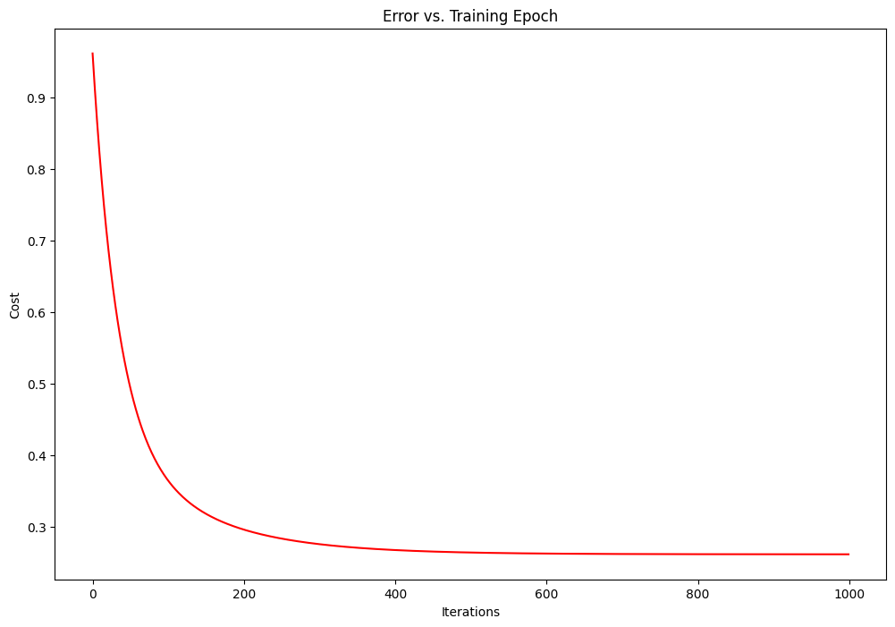

```python
fig, ax = plt.subplots(figsize=(12,8))
ax.plot(np.arange(iters), cost, 'r')
ax.set_xlabel('Iterations')
ax.set_ylabel('Cost')
ax.set_title('Error vs. Training Epoch')
```

# Do it with libraries in simple steps

#### Scikit-Learn Library

```python
!pip install scikit-learn
```

```python
# data.insert(0, 'Ones', 1)
cols = data.shape[1]
A = data.iloc[:,0:cols-1]
b = data.iloc[:,cols-1:cols]
A = np.asarray(A.values)
b = np.asarray(b.values)
```

```python
from sklearn import linear_model
model = linear_model.LinearRegression()
model.fit(np.asarray(A), np.asarray(b))
```

```
LinearRegression()
```

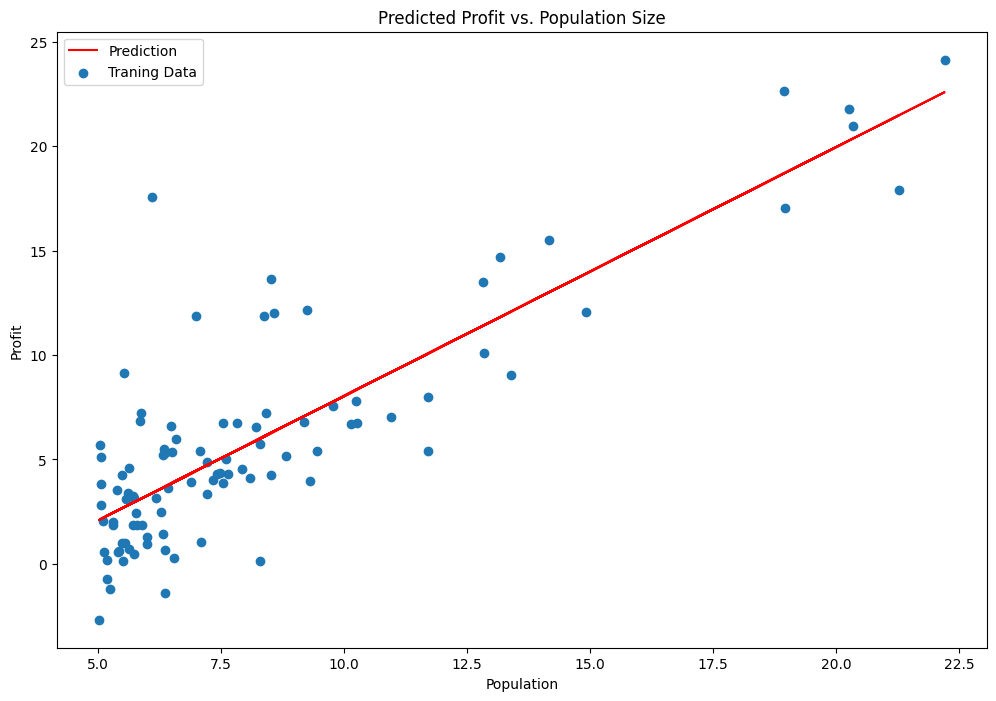

```python
x = np.array(A[:, 0])
f = model.predict(np.asarray(A)).flatten()

fig, ax = plt.subplots(figsize=(12,8))
ax.plot(x, f, 'r', label='Prediction')
ax.scatter(data.Population, data.Profit, label='Traning Data')
ax.legend(loc=2)
ax.set_xlabel('Population')
ax.set_ylabel('Profit')
ax.set_title('Predicted Profit vs. Population Size')
```

```python
model.coef_
```

```
array([[1.19303364]])
```

# Logistic Regression for Classification

#### # predict whether a student gets admitted to a university

```python
data = pd.read_csv('inputs/log_Reg_1.csv', header=None, names=['Exam 1', 'Exam 2', 'Admitted'])
data.head()
```

|  | Exam 1 | Exam 2 | Admitted |
| --- | --- | --- | --- |
| 0 | 34.623660 | 78.024693 | 0 |
| 1 | 30.286711 | 43.894998 | 0 |
| 2 | 35.847409 | 72.902198 | 0 |
| 3 | 60.182599 | 86.308552 | 1 |
| 4 | 79.032736 | 75.344376 | 1 |

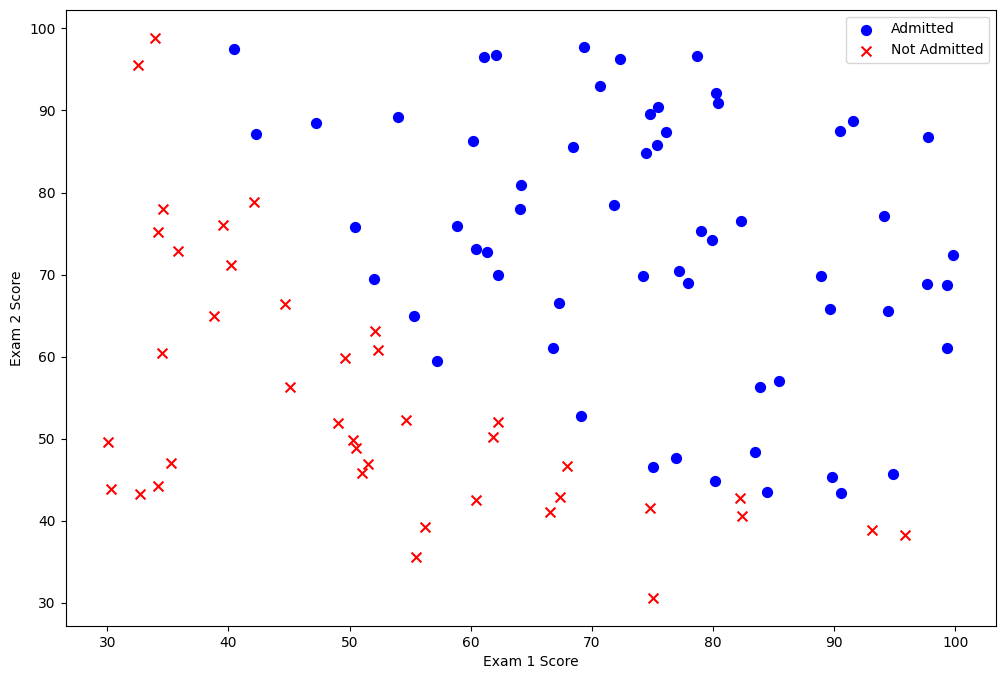

```python
positive = data[data['Admitted'].isin([1])]
negative = data[data['Admitted'].isin([0])]

fig, ax = plt.subplots(figsize=(12,8))
ax.scatter(positive['Exam 1'], positive['Exam 2'], s=50, c='b', marker='o', label='Admitted')
ax.scatter(negative['Exam 1'], negative['Exam 2'], s=50, c='r', marker='x', label='Not Admitted')
ax.legend()
ax.set_xlabel('Exam 1 Score')
ax.set_ylabel('Exam 2 Score')
```

```python
def sigmoid(z):
    return 1 / (1 + np.exp(-z))
```

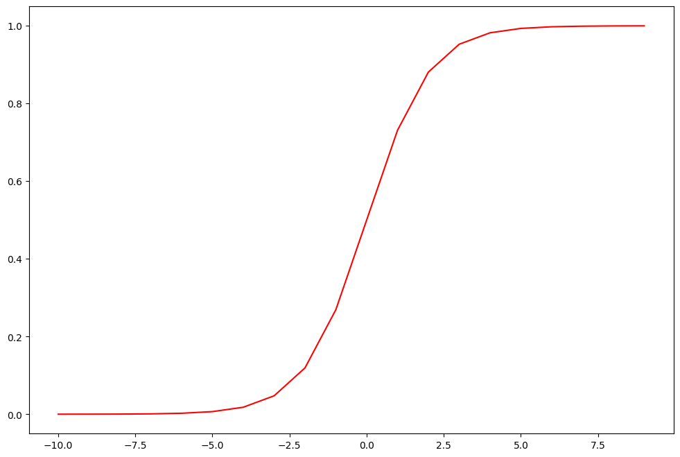

```python
nums = np.arange(-10, 10, step=1)
fig, ax = plt.subplots(figsize=(12,8))
ax.plot(nums, sigmoid(nums), 'r')
```

```python
def cost(W, X, y):
    W = np.matrix(W)
    X = np.matrix(X)
    y = np.matrix(y)
    first = np.multiply(-y, np.log(sigmoid(X * W.T)))
    second = np.multiply((1 - y), np.log(1 - sigmoid(X * W.T)))
    return np.sum(first - second) / (len(X))
```

## Explanation of the `cost` Function

The `cost` function calculates the cost function for logistic regression.

### Function Parameters:

- `W`: Vector of weights (model parameters).
- `X`: Matrix of feature inputs.
- `y`: Vector of target values (binary classification labels).

### Operations:

1. **Conversion to Matrices:**
   - The function converts the input vectors (`W`, `X`, `y`) into NumPy matrices using `np.matrix()`.
2. **Cost Calculation:**
   - `sigmoid(X * W.T)`: Calculates the sigmoid function for the logistic regression hypothesis. The sigmoid function maps any real-valued number to a value between 0 and 1.
   - `np.log()`: Computes the natural logarithm element-wise.
   - `np.multiply()`: Performs element-wise multiplication of matrices or vectors.
   - `first`: Calculates the cost for the 'y=1' case. Multiplies the negative of the actual target values (`-y`) by the logarithm of the predicted values for 'y=1'.
   - `second`: Calculates the cost for the 'y=0' case. Multiplies the negative of the complement of the actual target values `(1 - y)` by the logarithm of the complement of the predicted values for 'y=0'.
   - The function returns the sum of `first - second`, divided by the total number of observations (`len(X)`) to compute the average cost.

```python
# set A (training data) and b (target variable)
cols = data.shape[1]
A = data.iloc[:,0:cols-1]
b = data.iloc[:,cols-1:cols]

# convert to numpy arrays and initalize the parameter array theta
A = np.array(A.values)
b = np.array(b.values)
x = np.asmatrix(np.zeros((1, A.shape[1])))
```

```python
print(A.shape, b.shape, x.shape)
```

```
(100, 2) (100, 1) (1, 2)
```

```python
cost(x, A, b)
```

```
0.6931471805599453
```

```python
def gradient(W, X, y):
    W = np.matrix(W)
    X = np.matrix(X)
    y = np.matrix(y)

    parameters = int(W.ravel().shape[1])
    grad = np.zeros(parameters)

    error = sigmoid(X * W.T) - y

    for i in range(parameters):
        term = np.multiply(error, X[:,i])
        grad[i] = np.sum(term) / len(X)

    return grad
```

```python
gradient(x, A, b)
```

```
array([-12.00921659, -11.26284221])
```

```python
import scipy.optimize as opt
result = opt.fmin_tnc(func=cost, x0=x, fprime=gradient, args=(A, b))
result
```

```
  NIT   NF   F                       GTG
    0    1  6.931471805599453E-01   2.71072898E+02
    1    3  6.318091152740297E-01   7.84620903E-01
    2    5  6.312671871910226E-01   6.76949430E-01
    3    7  6.298208018782203E-01   1.62825170E-02
    4    9  6.298158872028060E-01   2.08330890E-05
tnc: fscale = 219.09
tnc: |fn-fn-1] = 6.97161e-09 -> convergence
    5   11  6.298158802311933E-01   5.94452661E-06
tnc: Converged (|f_n-f_(n-1)| ~= 0)
```

```
(array([0.01044469, 0.00043394]), 11, 1)
```

```python
def predict(W, X):
    probability = sigmoid(X * W.T)
    return [1 if x >= 0.5 else 0 for x in probability]
```

```python
x_min = np.matrix(result[0])
predictions = predict(x_min, A)
correct = [1 if ((a1 == 1 and b1 == 1) or (a1 == 0 and b1 == 0)) else 0 for (a1, b1) in zip(predictions, b)]
accuracy = (sum(map(int, correct)) % len(correct))
print('accuracy = {0}%'.format(accuracy))
```

```
accuracy = 60%
```

```python
# set A (training data) and b (target variable)
data.insert(0, 'Ones', 1)

cols = data.shape[1]
A = data.iloc[:,0:cols-1]
b = data.iloc[:,cols-1:cols]

# convert to numpy arrays and initalize the parameter array theta
A = np.array(A.values)
b = np.array(b.values)
x = np.asmatrix(np.zeros((1, A.shape[1])))
```

```python
result = opt.fmin_tnc(func=cost, x0=x, fprime=gradient, args=(A, b))
result
```

```
  NIT   NF   F                       GTG
    0    1  6.931471805599453E-01   2.71082898E+02
    1    3  6.318123602631536E-01   7.89087138E-01
    2    5  5.892425221302822E-01   7.39226603E+01
    3    7  4.227824068839701E-01   1.85265786E+01
    4    9  4.072926970186691E-01   1.68671133E+01
    5   11  3.818854914522947E-01   1.07735097E+01
    6   13  3.786234888874194E-01   2.31584930E+01
tnc: stepmx = 1000
    7   16  2.389268293310401E-01   3.00822027E+00
    8   18  2.047203891287692E-01   1.52227675E-01
    9   20  2.046713899074760E-01   6.62495132E-02
   10   22  2.035303163184269E-01   9.30780696E-04
tnc: fscale = 32.7775
   11   24  2.035293522095244E-01   8.07206972E-06
   12   26  2.035251114014784E-01   1.80212843E-04
   13   28  2.034984107120675E-01   5.02862434E-04
   14   30  2.034978380505887E-01   9.90612627E-06
   15   32  2.034977906457924E-01   3.77371210E-06
   16   34  2.034977387797661E-01   1.94466650E-05
   17   36  2.034977015894745E-01   2.38492699E-13
tnc: |pg| = 1.48991e-08 -> local minimum
   17   36  2.034977015894745E-01   2.38492699E-13
tnc: Local minima reach (|pg| ~= 0)
```

```
(array([-25.16131865,   0.20623159,   0.20147149]), 36, 0)
```

```python
x_min = np.matrix(result[0])
predictions = predict(x_min, A)
correct = [1 if ((a1 == 1 and b1 == 1) or (a1 == 0 and b1 == 0)) else 0 for (a1, b1) in zip(predictions, b)]
accuracy = (sum(map(int, correct)) % len(correct))
print('accuracy = {0}%'.format(accuracy))
```

```
accuracy = 89%
```

# Do it with libraries in simple steps

```python
from sklearn import linear_model
logistic = linear_model.LogisticRegression()
print('LogisticRegression score: %f'
      % logistic.fit(A, b).score(A, b))
```

```
LogisticRegression score: 0.890000
```

```python
logistic.coef_
```

```
array([[-4.19885857e-08,  2.05354461e-01,  2.00583554e-01]])
```